README

Author

# Drought index assessment for groundwater drought prediction

**Author:** Pietari Pöykkö  
**Contact:** pietari.poykko@oulu.fi  
**Organization:** University of Oulu  
**Website:** https://www.oulu.fi/en/researchers/pietari-poykko (Personal site not yet available)

## Project Overview

Groundwater (GW) droughts should be predicted in advance, as such conditions have important financial and ecological consequences. The accurate prediction of GW conditions is difficult due to sparse monitoring network and diverse local conditions. This reseach project aims to evaluate the suitability and accuracy of widely available drought indices for GW drought prediction. The drought indices are here calculated from readily available data. The time series of indices are then correlated with natural-state GW levels to assess the prediction power (lead-times, accuracy).

Long-term drought trends in northern Europe are uncertain (Karlsson et al., 2014; Teutschbein et al., 2025), more frequent and intense droughts are predicted by climate projections. Groundwater droughts remain underexplored despite their importance for baseflow and water supply. In Finland, where groundwater and surface water are closely linked, and groundwater constitutes almost half of the water supply (Lai et al., 2018), an integrated approach to drought assessment is essential.

Schneider et al. (2025) use hydrological principles and drought indices to evaluate drought propagation in a hydrological model. Gao et al. (2016) investigated droughts affecting forest health with a related method using drought indices. A similar approach is used here to evaluate the accuracy, validity, and lead-time of drought indices to enhance the predictions of groundwater conditions.

#### Research questions:

- Which drought index has the best prediction power on GW drought (in the subarctic Finland)?
- How far into the future can the indices predict GW levels?
- Does the latitude, soil, or the season affect index performance? These questions were still left unanswered due to issues with the selected datasets. Details below and in `SE4_results_viz.html`.

## Data Sources

The study area is Finland, with analyzed groundwater data extending from 1970s to 2025.

### Published Data Sources

**Important**

Only the 1st and 3rd data sources were ultimately used.

Name

Source

Description

Access

URLs

Details

Citation

GW level

[Finnish Environment Institute](https://syke.fi/en)

Manual measure  
ments of GW level from the national hydrological moni  
toring network

Download

[Through Hertta portal](http://syke.fi/en/environmental-data/maps-and-information-services/open-environmental-information-systems) [Metadata](https://ckan.ymparisto.fi/dataset/pohjavesitietoaineisto-povet1)

…

Finnish Environment Institute, Economic Development Centres, 2025. Groundwater dataset POVET.

GW areas

Finnish Environment Institute

The geometries and descriptions of mapped, anthropogenically classified GW areas

Download

Through Hertta portal [Metadata](https://ckan.ymparisto.fi/dataset/pohjavesialueet)

…

Finnish Environment Institute, 2026. Groundwater areas.

SPI & SPEI  
monthly drought indices

ECMWF Climate Data Store

Monthly values for 1, 3, 6, 12, 24, 36, 48 month accumula-  
tion periods. Global, gridded, based on ERA5

API

[Dataset and metadata](https://doi.org/10.24381/9bea5e16)

Keune, J., Di Giuseppe, F., Barnard, C. et al. ERA5–Drought: Global drought indices based on ECMWF reanalysis. Sci Data 12, 616 (2025). (10.1038/s41597-025-04896-y)

Temperature  
and  
precipitation

[Finnish Meteorological Institute](https://fmi.fi/en)

Gridded dataset of T & P observations

Download

[Download link](https://avoindata.suomi.fi/data/fi/dataset/saahavaintojen-hilamuotoiset-kuukausiarvot) [Metadata](http://paikkatietohakemisto.fi/geonetwork/srv/api/records/b5ac0243-3da6-47ed-96b0-1867cdeda838)

…

…

Tentative:  
Global T & P

Climatic Research Unit (Univ. of East Anglia) and NCAS

T & P global time series for reference

Download

[Download link](https://crudata.uea.ac.uk/cru/data/hrg/cru_ts_4.09) [Metadata DOI](https://doi.org/10.6084/m9.figshare.11980500)

Harris, I., Osborn, T.J., Jones, P. et al. Version 4 of the CRU TS monthly high-resolution gridded multivariate climate dataset. Sci Data 7, 109 (2020). (10.1038/s41597-020-0453-3)

Surface  
geology  
(200k)

[Geological Survey of Finland](https://gtk.fi/en)

Approximate classification of surficial soil deposits

Download

[Hakku link](https://hakku.gtk.fi/fi/locations?id=3) [Metadata](https://tupa.gtk.fi/paikkatieto/meta/maapera_200k.html)

[License](https://gtk.fi/avoinlisenssi)

…

Surficial  
deposit  
thickness

Geological Survey of Finland

…

Download

[Hakku link](https://hakku.gtk.fi/fi/locations?id=113) [Metadata](https://tupa.gtk.fi/paikkatieto/meta/maapeitepaksuus_1000k.html)

[License](https://gtk.fi/avoinlisenssi)

…

Self-  
calibrating  
Palmer  
Drought  
Severity  
Index

Climatic Research Unit (Univ. of East Anglia)

Monthly global values of scPDSI derived from CRU-TS v4.09. 1901-2024 and resolution of 0.5°*0.5°

Download

[UEA-CRU link](https://crudata.uea.ac.uk/cru/data/drought/#global) Metadata in readme of the above, and in the NetCDF files

[License](http://opendatacommons.org/licenses/odbl/1.0)

van der Schrier G, Barichivich J, Briffa KR and Jones PD (2013) A scPDSI-based global data set of dry and wet spells for 1901-2009. J. Geophys. Res. Atmos. 118, 4025-4048 (10.1002/jgrd.50355).

Barichivich J, Osborn TJ, Harris I, van der Schrier G and Jones PD (2025) Monitoring global drought using the self- calibrating Palmer Drought Severity Index [in “State of the Climate in 2024”]. Bull. Amer. Meteor. Soc., 106, S77-S78 (10.1175/BAMS-D-25-0102.1)

### Data Access Notes

[Hertta](https://syke.fi/en/environmental-data/maps-and-information-services/open-environmental-information-systems), the open data portal of the [Finnish Environment Institute](https://syke.fi/en), requires the creation of a free user account. The portal is mostly available in English. There is no one-button solution to download either the GW observations or the GW area information.  
Hakku requires order details, such as email, for digital delivery of spatial data product downloads.  
The automated downloads through the European Centre for Medium-Range Weather Forecasts (ECMWF) API requires an API key, obtained via creating a free account. The script tries to ask for this automatically

## Methods Summary

The GW source data will be quality controlled prior to analysis. Quality control steps have been outlined in Pöykkö et al. (2026).  
**Model Framework:** GW is aggregated to monthly values due to gaps and sparse measurement interval. This also matches the temporal resolution of the drought indices.  
The GW levels are converted into Standardized Groundwater Index (SGI) for individual pipes. Also, monitoring stations (~10 pipes) are aggregated their own time series for comparison. The drought indices available in the above mentioned dataset accumulate the drought conditions in the environment into a standardized numerical value. The correlations and concurrency between the SGI and drought index time series are studied. Further analysis was intended, but issues with the datasets postponed it.

## Repository Structure

| Folder/File | Description |
| --- | --- |
| `inputs/` | Stores all input data required |
| `inputs/manual/` | Input data requiring a manual download. Contents not committed to repository. |
| `inputs/auto/` | Stores automatically downloaded datasets. Contents not committed to repository. |
| `analysis_ready/` | Analysis-ready datasets (No saved model outputs, model configuration files, predictions) |
| `figures/` | Figures, tables, graphs, and data-derivatives (e.g. summary statistics) displayed in manuscript text |
| `run_reproducibility.R` | Reproducibility wrapper |

## How to Reproduce

0. Install the R language v.4.5.3.
1. Install the Positron IDE, which will come bundled with Quarto. Alternatively install Quarto CLI.
2. Download all datasets with “Download” access in the above table. Place them directly into `inputs/manual/`.  
   (Only the GW dataset used. Contact for details on what data to download…)
3. Run the file `run_reproducibility.R`.

### Computational requirements

The code has been tested on:

- Windows operating system
- Intel Core Ultra 5 125H, 14 cores
- 32 Gb of RAM  
  Any sufficiently modern computer should manage to run the code. Linux or MacOS systems should also be compatable.

### Data access configurations

The drought index data downloads require an API key for European Centre for Medium-Range Weather Forecasts services. This key can be obtained by registering an ECMWF account on https://www.ecmwf.int/, and viewing the key from your personal profile. The script should ask for this key automatically. It can also be provided by running the command `ecmwfr::wf_set_key()`

## Results

The scope of this project was initially too broad. Ultimately, only two main datasets were used: the Finnish national GW dataset and the ERA5-based drought index (SPI & SPEI) dataset. The main reason for this was the overhead related to learning to use and format these notebooks. Working with large tables with a lot of text and links (the data sources table above) is also a huge pain! It would be wiser to format such table in an excel file, and to convert to Markdown only as needed.

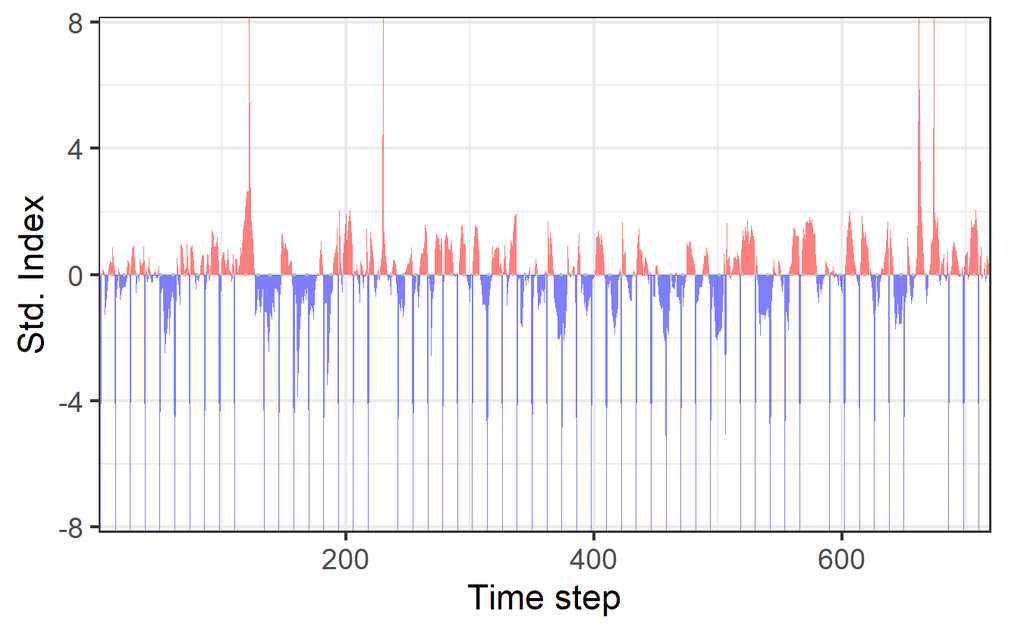

These errors make it impossible to study the relationships between GW levels and the drought indices:

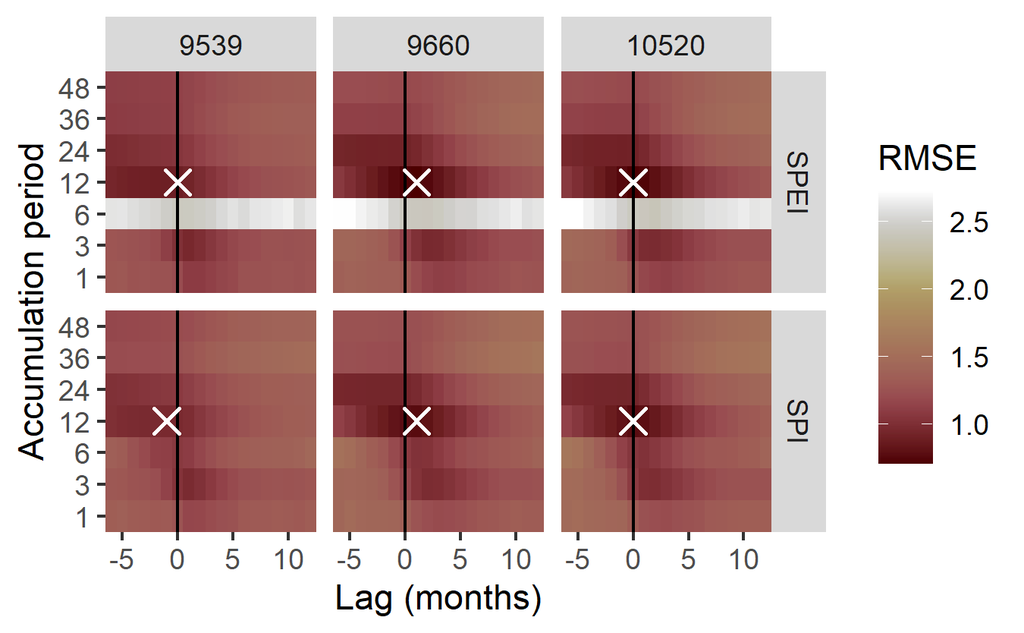

Similar bad time series were very prevalent across the dataset:

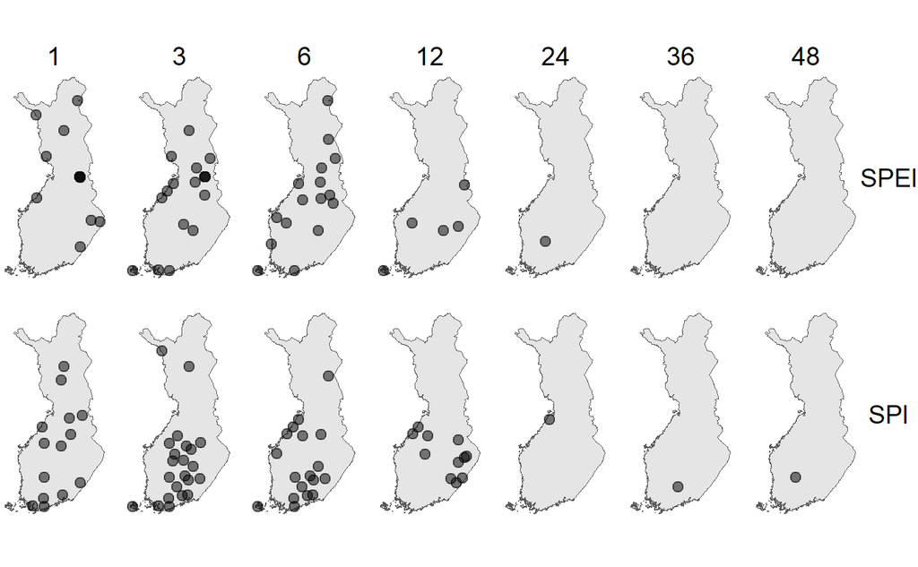

The code also produces intermediary files suitable for further analysis into the folder `analysis-ready`. These are produced by and documented in `SE2_data_processing.qmd`

## License

MIT

## Contribution Guidelines

Contributions that improve the quality, clarity, and reproducibility of this project are welcome.

- Open an issue before making major or result-affecting changes.
- Keep pull requests focused and clearly describe what changed and why.
- Follow existing code style and update documentation as needed.
- Do not modify code or data used to reproduce published results without discussion.
- Ensure workflows remain reproducible (environment, dependencies, random seeds).
- Do not commit large or restricted datasets; respect data licenses. By contributing, you agree that your work will be released under the project’s license.

## References

- Gao, Y., Markkanen, T., Thum, T., Aurela, M., Lohila, A., Mammarella, I., Kämäräinen, M., Hagemann, S., Aalto, T., 2016. Assessing various drought indicators in representing summer drought in boreal forests in Finland. Hydrol. Earth Syst. Sci. 20, 175–191. https://doi.org/10.5194/hess-20-175-2016
- Lai, T.-Y., Salminen, J., Jäppinen, J.-P., Koljonen, S., Mononen, L., Nieminen, E., Vihervaara, P., Oinonen, S., 2018. Bridging the gap between ecosystem service indicators and ecosystem accounting in Finland. Ecological Modelling 377, 51–65. https://doi.org/10.1016/j.ecolmodel.2018.03.006
- Karlsson, I.B., Sonnenborg, T.O., Jensen, K.H., Refsgaard, J.C., 2014. Historical trends in precipitation and stream discharge at the Skjern River catchment, Denmark. Hydrology and Earth System Sciences 18, 595–610. https://doi.org/10.5194/hess-18-595-2014
- Pöykkö et al., 2026. TBD.
- Schneider, R., Stisen, S., Hansen, M.F.T., Andreasen, M., Nilsson, B., Hinsby, K., Henriksen, H.J., Seidenfaden, I.K., 2025. Drought dynamics across the hydrological cycle – an extensive validation of the National Hydrological Model of Denmark. EGUsphere 1–53. https://doi.org/10.5194/egusphere-2025-5373
- Teutschbein, C., Grabs, T., Giese, M., Todorović, A., Barthel, R., 2025. Drought propagation in high-latitude catchments: insights from a 60-year analysis using standardized indices. Natural Hazards and Earth System Sciences 25, 2541–2564. https://doi.org/10.5194/nhess-25-2541-2025